# Parenting Observational Study E2

Total number of bids (successful and unsuccessful)

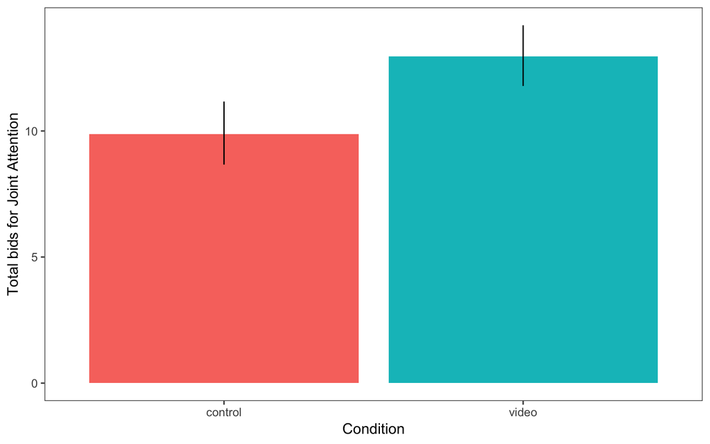

```r
dem <- read.csv("../anonymized_demographics_parenting_obs_e2.csv", header=T)
dem$age = as.numeric(as.character(dem$age))
d$age = NULL
d <- d %>% left_join(dem, by=c("sid" = "SID")) %>%
  filter(age <= 2.0) # 1 kid exactly 2...

save(d, file="Exp2_joint_attention_data.RData")

d$condition <- factor(d$condition, levels = c("con", "exp"), labels = c("control", "video"))

ms_bids <- d %>%
  group_by(condition) %>%
  multi_boot_standard(col = "bids_tot")

ggplot(ms_bids, aes(x = condition, y = mean, fill = condition)) +
  geom_bar(stat="identity") +
  geom_linerange(aes(ymin = ci_lower, ymax = ci_upper),
             position = position_dodge(width = .9))+
  xlab("Condition") + ylab("Total bids for Joint Attention") +
  langcog::scale_colour_solarized() + ggthemes::theme_few() + theme(legend.position="none")
```

Total episodes of joint attention.

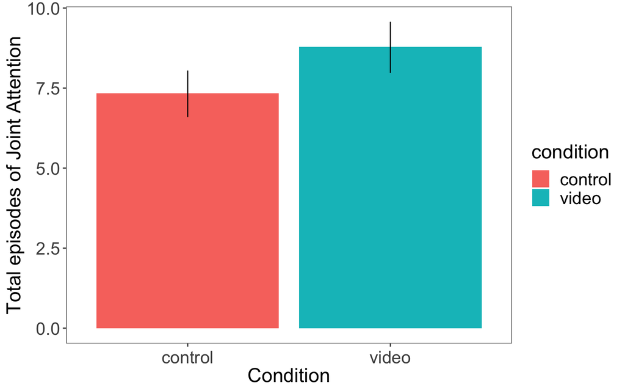

```r
ms_tja <- d %>%
  group_by(condition) %>%
  multi_boot_standard(col = "total_ja")

ggplot(ms_tja, aes(x = condition, y = mean, fill = condition)) +
  geom_bar(stat="identity") +
  geom_linerange(aes(ymin = ci_lower, ymax = ci_upper),
             position = position_dodge(width = .9))+
  xlab("Condition") +
  ylab("Total episodes of Joint Attention") +
  langcog::scale_colour_solarized()  + ggthemes::theme_few() +
  theme(legend.title = element_text(size=18),
        legend.text = element_text(size=16),
        axis.text.x  = element_text(vjust=0.5, size=16),
        axis.title.x = element_text(size=18),
        axis.text.y  = element_text(vjust=0.5, size=16),
        axis.title.y = element_text(size=18))
```

Episodes of passive joint attention.

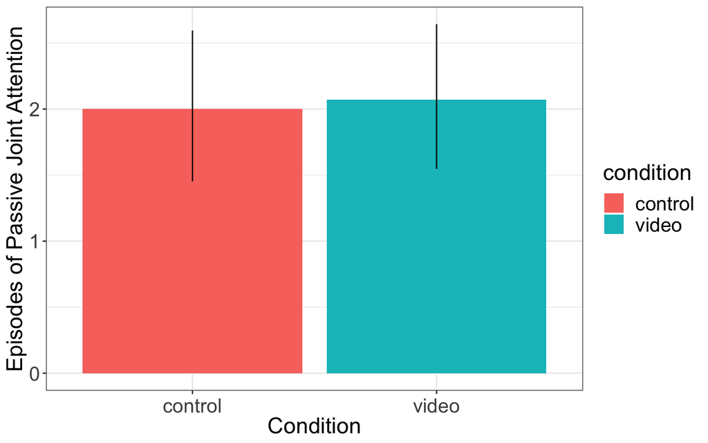

```r
ms_pja <- d %>%
  group_by(condition) %>%
  multi_boot_standard(col = "pja")

ggplot(ms_pja, aes(x = condition, y = mean, fill = condition)) +
  geom_bar(stat="identity") +
  geom_linerange(aes(ymin = ci_lower, ymax = ci_upper),
             position = position_dodge(width = .9))+
  xlab("Condition") +
  ylab("Episodes of Passive Joint Attention")  +
  langcog::scale_colour_solarized() +
  theme(legend.title = element_text(size=18),
        legend.text = element_text(size=16),
        axis.text.x  = element_text(vjust=0.5, size=16),
        axis.title.x = element_text(size=18),
        axis.text.y  = element_text(vjust=0.5, size=16),
        axis.title.y = element_text(size=18))
```

Episodes of coordinated joint attention

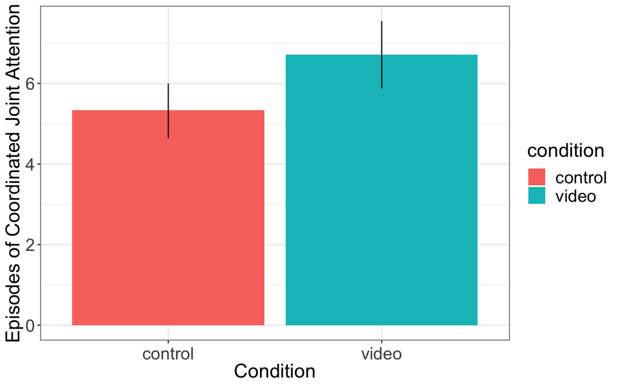

```r
ms_cja <- d %>%
  group_by(condition) %>%
  multi_boot_standard(col = "cja")

ggplot(ms_cja, aes(x = condition, y = mean, fill = condition)) +
  geom_bar(stat="identity") +
  geom_linerange(aes(ymin = ci_lower, ymax = ci_upper),
             position = position_dodge(width = .9))+
  xlab("Condition") +
  ylab("Episodes of Coordinated Joint Attention")  +
  langcog::scale_colour_solarized()  +
  theme(legend.title = element_text(size=18),
        legend.text = element_text(size=16),
        axis.text.x  = element_text(vjust=0.5, size=16),
        axis.title.x = element_text(size=18),
        axis.text.y  = element_text(vjust=0.5, size=16),
        axis.title.y = element_text(size=18))
```

Total duration of passive joint attention.

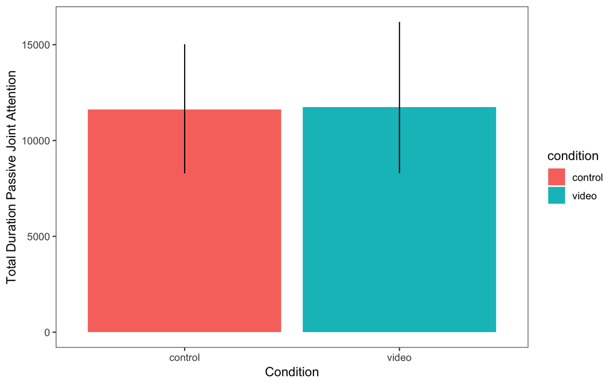

```r
ms_lpja <- d %>%
  filter(!is.na(condition))%>%
  group_by(condition) %>%
  multi_boot_standard(col = "pja_length")

ggplot(ms_lpja, aes(x = condition, y = mean, fill = condition)) +
  geom_bar(stat="identity") +
  geom_linerange(aes(ymin = ci_lower, ymax = ci_upper),
             position = position_dodge(width = .9))+
  xlab("Condition") +
  ylab("Total Duration Passive Joint Attention")  +
  langcog::scale_colour_solarized()  +
  ggthemes::theme_few()
```

Total duration of coordinated joint attention.

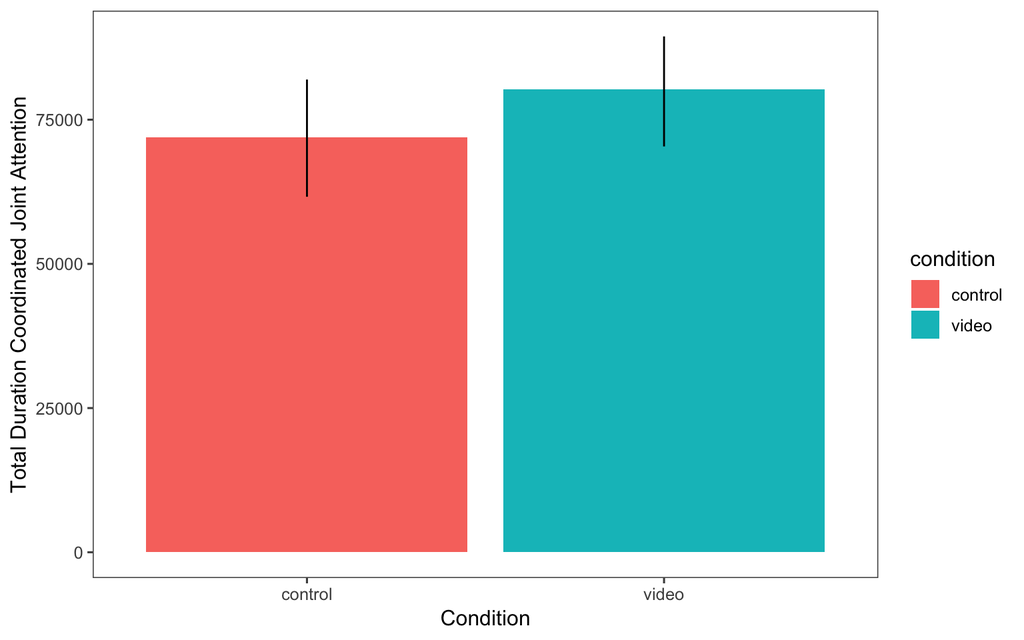

```r
ms_lcja <- d %>%
  filter(!is.na(condition))%>%
  group_by(condition) %>%
  multi_boot_standard(col = "cja_length")

ggplot(ms_lcja, aes(x = condition, y = mean, fill = condition)) +
  geom_bar(stat="identity") +
  geom_linerange(aes(ymin = ci_lower, ymax = ci_upper),
             position = position_dodge(width = .9))+
  xlab("Condition") +
  ylab("Total Duration Coordinated Joint Attention")  +
  langcog::scale_colour_solarized()  +
  ggthemes::theme_few()
```

##Demographics

###Child gender

Total bids by gender.

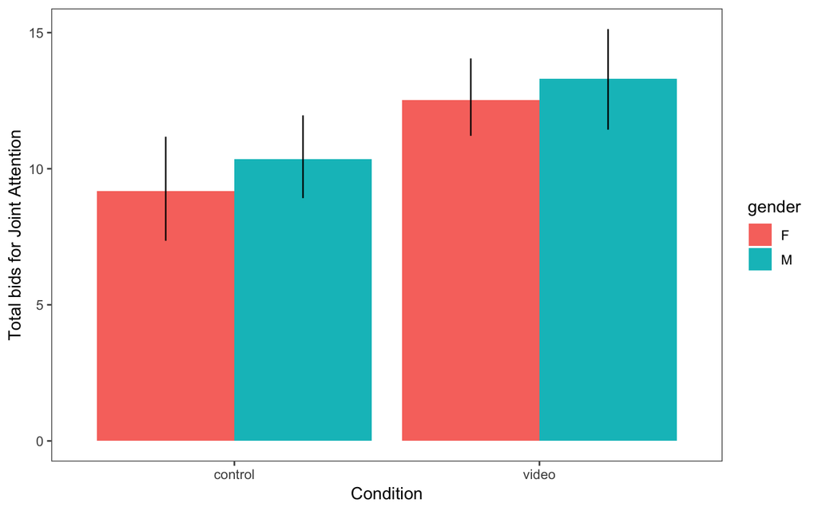

```r
# total bids
ms_bids <- d %>%
  group_by(condition, gender) %>%
  multi_boot_standard(col = "bids_tot")

ggplot(ms_bids, aes(x = condition, y = mean, fill=gender)) +
  geom_bar(stat="identity", position = "dodge") +
  geom_linerange(aes(ymin = ci_lower, ymax = ci_upper),
             position = position_dodge(width = .9))+
  xlab("Condition") +
  ylab("Total bids for Joint Attention")  +
  langcog::scale_colour_solarized()  +
  ggthemes::theme_few()
```

Total duration of passive joint attention by gender

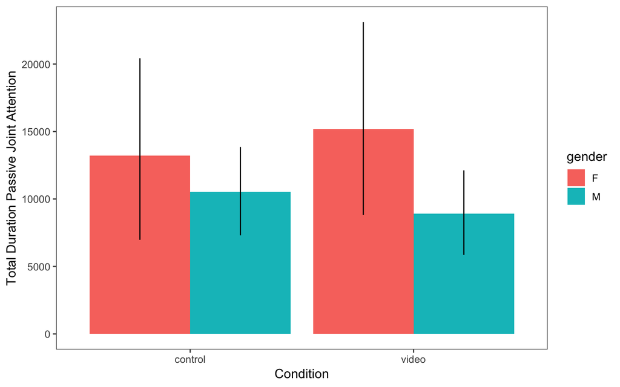

```r
ms_lpja <- d %>%
  filter(!is.na(condition))%>%
  group_by(condition, gender) %>%
  multi_boot_standard(col = "pja_length")

ggplot(ms_lpja, aes(x = condition, y = mean, fill=gender)) +
  geom_bar(stat="identity", position = "dodge") +
  geom_linerange(aes(ymin = ci_lower, ymax = ci_upper),
             position = position_dodge(width = .9))+
  xlab("Condition") +
  ylab("Total Duration Passive Joint Attention")  +
  langcog::scale_colour_solarized()  +
  ggthemes::theme_few()
```

Total duration of coordinated joint attention by gender

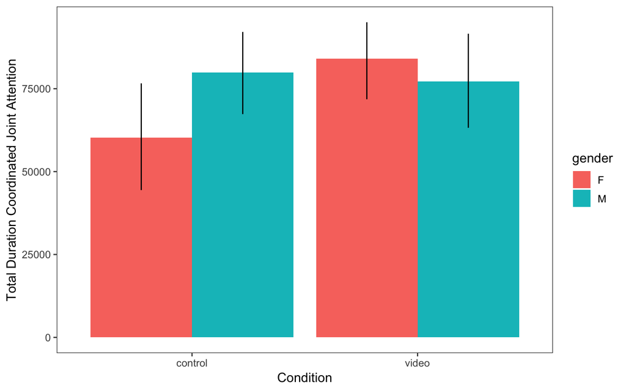

```r
ms_lcja <- d %>%
  filter(!is.na(condition))%>%
  group_by(condition, gender) %>%
  multi_boot_standard(col = "cja_length")

ggplot(ms_lcja, aes(x = condition, y = mean, fill=gender)) +
  geom_bar(stat="identity", position = "dodge") +
  geom_linerange(aes(ymin = ci_lower, ymax = ci_upper),
             position = position_dodge(width = .9))+
  xlab("Condition") +
  ylab("Total Duration Coordinated Joint Attention")  +
  langcog::scale_colour_solarized()  +
  ggthemes::theme_few()
```

###Child age

Children were separated into 3 age groups: 6-12 months, 12-18 months, and 18-24 months.

Total bids by age.

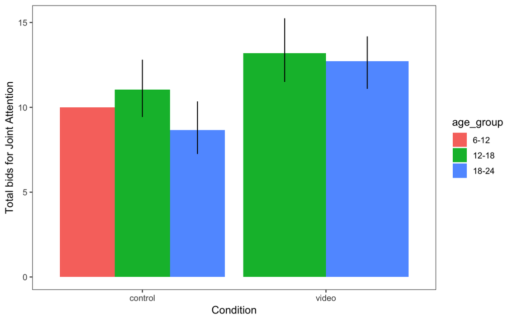

```r
# total bids
d$age_group = ifelse(d$age<1, "6-12", ifelse(d$age<1.5, "12-18", "18-24"))
d$age_group <- factor(d$age_group , levels = c("6-12","12-18", "18-24"))

ms_bids <- d %>%
  group_by(condition, age_group) %>%
  multi_boot_standard(col = "bids_tot")

ggplot(ms_bids, aes(x = condition, y = mean, fill=age_group)) +
  geom_bar(stat="identity", position= "dodge") +
  geom_linerange(aes(ymin = ci_lower, ymax = ci_upper),
             position = position_dodge(width = .9))+
  xlab("Condition") +
  ylab("Total bids for Joint Attention")  +
  langcog::scale_colour_solarized()  +
  ggthemes::theme_few()
```

Total duration of passive joint attention by age

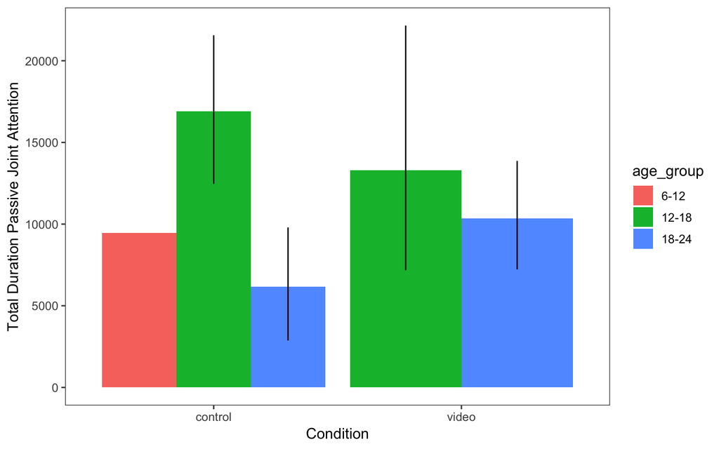

```r
ms_lpja <- d %>%
  filter(!is.na(condition))%>%
  group_by(condition, age_group) %>%
  multi_boot_standard(col = "pja_length")

ggplot(ms_lpja, aes(x = condition, y = mean, fill = age_group)) +
  geom_bar(stat="identity", position = "dodge") +
  geom_linerange(aes(ymin = ci_lower, ymax = ci_upper),
             position = position_dodge(width = .9))+
  xlab("Condition") +
  ylab("Total Duration Passive Joint Attention")  +
  langcog::scale_colour_solarized()  +
  ggthemes::theme_few()
```

Total duration of coordinated joint attention by age

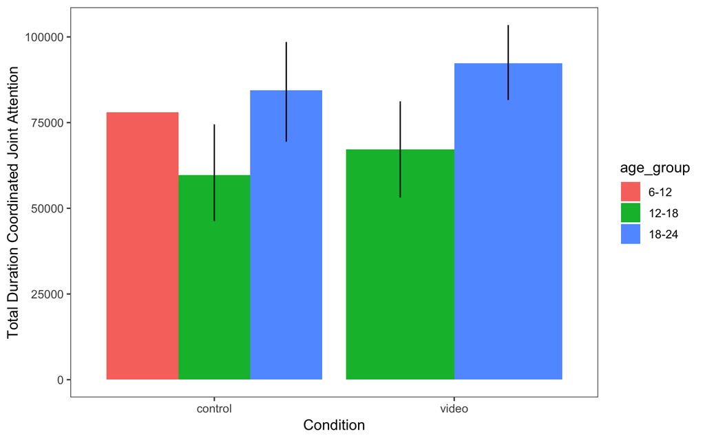

```r
ms_lcja <- d %>%
  filter(!is.na(condition))%>%
  group_by(condition, age_group) %>%
  multi_boot_standard(col = "cja_length")

ggplot(ms_lcja, aes(x = condition, y = mean, fill = age_group)) +
  geom_bar(stat="identity", position = "dodge") +
  geom_linerange(aes(ymin = ci_lower, ymax = ci_upper),
             position = position_dodge(width = .9))+
  xlab("Condition") +
  ylab("Total Duration Coordinated Joint Attention")  +
  langcog::scale_colour_solarized()  +
  ggthemes::theme_few()
```